# Wine Clustering

Amine Agrane & Lydia Khelfane

10/02/2021

# K-means clustering on the wine dataset

# Objective

The objective of this report is to describe the implementation of a k-Means algorithm and discuss the design decisions. We test our k-Means algorithm on the Wine dataset and discuss the performance of it. We are using clustering for classifying the colour.

#### Reading the data

#Reading data

```r
data_wine <- as.data.frame( read.csv(file = './data/winequality.csv', sep=',', stringsAsFactors=F))
```

```r
# It show the first few rows
head(data_wine)
```

|  | fixed.acidity | volatile.acidity | citric.acid | residual.sugar | chlorides | free.sulfur.dioxide | total.sulfur.dioxide | density | pH | sulphates | alcohol | quality | color |
| --- | --- | --- | --- | --- | --- | --- | --- | --- | --- | --- | --- | --- | --- |
| 1 | 7.3 | 0.65 | 0.00 | 1.2 | 0.065 | 15 | 21 | 0.9946 | 3.39 | 0.47 | 10.0 | 7 | red |
| 2 | 7.8 | 0.88 | 0.00 | 2.6 | 0.098 | 25 | 67 | 0.9968 | 3.20 | 0.68 | 9.8 | 5 | red |
| 3 | 7.8 | 0.76 | 0.04 | 2.3 | 0.092 | 15 | 54 | 0.9970 | 3.26 | 0.65 | 9.8 | 5 | red |
| 4 | 11.2 | 0.28 | 0.56 | 1.9 | 0.075 | 17 | 60 | 0.9980 | 3.16 | 0.58 | 9.8 | 6 | red |
| 5 | 7.4 | 0.70 | 0.00 | 1.9 | 0.076 | 11 | 34 | 0.9978 | 3.51 | 0.56 | 9.4 | 5 | red |
| 6 | 7.4 | 0.66 | 0.00 | 1.8 | 0.075 | 13 | 40 | 0.9978 | 3.51 | 0.56 | 9.4 | 5 | red |

### Prepare the data:

#### Transform the color into numeric values

After we uploaded the data wine, we drop the quality label and we digitize the color data, The new values of the color feature will bz :

- 1 for red wine.
- 0 for white wine.

```r
# %% [code]
colSums(is.na(data_wine))
```

```
       fixed.acidity     volatile.acidity          citric.acid
                   0                    0                    0
      residual.sugar            chlorides  free.sulfur.dioxide
                   0                    0                    0
total.sulfur.dioxide              density                   pH
                   0                    0                    0
           sulphates              alcohol              quality
                   0                    0                    0
               color
                   0
```

```r
# %% [code]
Quality<-data_wine$quality
data_wine$quality<-NULL

# %% [code]
data_wine$color<- ifelse(data_wine$color == "red",1,0)
```

#### Scale the dataset

We also use the `scale()` function to scanle our dataset, `scale`, will calculate the mean and standard deviation of the entire vector/column, then recompute each elements of a vector by subtracting the mean and dividing by the sd. (If you use scale(x, scale=FALSE), it will only subtract the mean but not divide by the std deviation.)

```r
# scale the dataset
scaled_dataset_wine <- scale(data_wine)
scaled_dataset_wine <- as.data.frame(scaled_dataset_wine)

# merge the data set with the new numeric value for color
scaled_dataset_wine_for_predict <- cbind(scaled_dataset_wine, color = data_wine$color)
scaled_dataset_wine_for_predict <- as.data.frame(scaled_dataset_wine_for_predict)


head(data_wine)
```

|  | fixed.acidity | volatile.acidity | citric.acid | residual.sugar | chlorides | free.sulfur.dioxide | total.sulfur.dioxide | density | pH | sulphates | alcohol | color |
| --- | --- | --- | --- | --- | --- | --- | --- | --- | --- | --- | --- | --- |
| 1 | 7.3 | 0.65 | 0.00 | 1.2 | 0.065 | 15 | 21 | 0.9946 | 3.39 | 0.47 | 10.0 | 1 |
| 2 | 7.8 | 0.88 | 0.00 | 2.6 | 0.098 | 25 | 67 | 0.9968 | 3.20 | 0.68 | 9.8 | 1 |
| 3 | 7.8 | 0.76 | 0.04 | 2.3 | 0.092 | 15 | 54 | 0.9970 | 3.26 | 0.65 | 9.8 | 1 |
| 4 | 11.2 | 0.28 | 0.56 | 1.9 | 0.075 | 17 | 60 | 0.9980 | 3.16 | 0.58 | 9.8 | 1 |
| 5 | 7.4 | 0.70 | 0.00 | 1.9 | 0.076 | 11 | 34 | 0.9978 | 3.51 | 0.56 | 9.4 | 1 |
| 6 | 7.4 | 0.66 | 0.00 | 1.8 | 0.075 | 13 | 40 | 0.9978 | 3.51 | 0.56 | 9.4 | 1 |

Lets check correlation between various columns of Wine Quality data

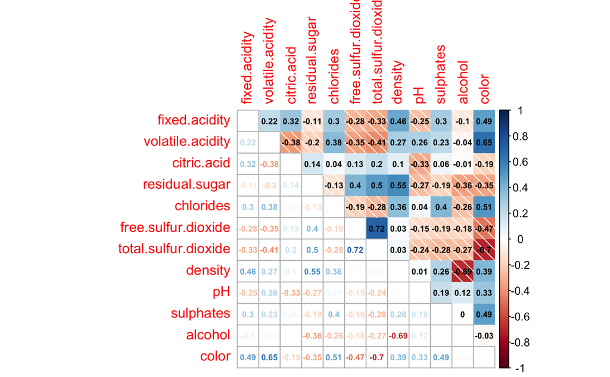

```r
dataset_wine_numcols <- scaled_dataset_wine[, sapply(scaled_dataset_wine, is.numeric)]


corrplot.mixed(
  cor(dataset_wine_numcols),
  upper = "shade",
  lower = "number",
  tl.pos = "lt",
  addCoef.col = "black",
  number.cex = .6
)
```